# Stat 563 Project- Final

```r
# Function to compute metrics for each model
compute_model_metrics <- function(model, data) {
  sse <- sum(residuals(model)^2)
  r2 <- summary(model)$r.squared
  adj_r2 <- summary(model)$adj.r.squared
  aic <- AIC(model)
  bic <- BIC(model)

  # Calculate Cp (Mallow's Cp)
  cp <- sse / (var(model$residuals) * (nrow(data) - length(coef(model)))) + 2 * length(coef(model)) - nrow(data)

  # Calculate PRESS
  press <- sum((residuals(model) / (1 - lm.influence(model)$hat))^2)

  return(data.frame(SSE = sse, R2 = r2, Adj_R2 = adj_r2, AIC = aic, BIC = bic, Cp = cp))
}

# Compute metrics for all models
metrics_forward <- compute_model_metrics(forward_model, refined_data)
metrics_backward <- compute_model_metrics(backward_model, refined_data)
metrics_both <- compute_model_metrics(both_model, refined_data)

# Combine the results
results <- rbind(
  cbind(Model = "Forward", metrics_forward),
  cbind(Model = "Backward", metrics_backward),
  cbind(Model = "Both", metrics_both)
)

# Display the table
results
```

```
##      Model       SSE        R2    Adj_R2        AIC        BIC     Cp
## 1  Forward 904.82076 0.7145210 0.7140845  -3856.994  -3613.584 -18934
## 2 Backward  99.33717 0.9686582 0.9686070 -45817.072 -45557.959 -18930
## 3     Both 904.82076 0.7145210 0.7140845  -3856.994  -3613.584 -18934
```

Based on the comparison of the three models, **Backward Selection** outperforms the other methods with the lowest SSE (99.34), highest R² (0.9687), and Adjusted R² (0.9686), as well as the most favorable AIC (-45817.07) and BIC (-45557.96), indicating superior model fit and efficiency. In contrast, the **Forward Selection** and **Both** models yield identical results, with higher SSE (904.82), lower R² (0.7145), and Adjusted R² (0.7141), along with less favorable AIC (-3856.99) and BIC (-3613.58), making them less effective compared to Backward Selection. Thus, Backward Selection demonstrates the best balance between model fit and complexity among the three methods.

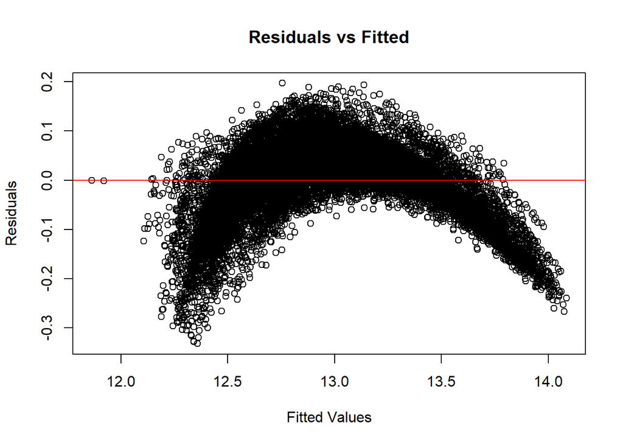

```r
 # Residuals vs Fitted
plot(resid(backward_model) ~ fitted(backward_model),
     main = "Residuals vs Fitted",
     xlab = "Fitted Values",
     ylab = "Residuals")
abline(h = 0, col = "red")
```

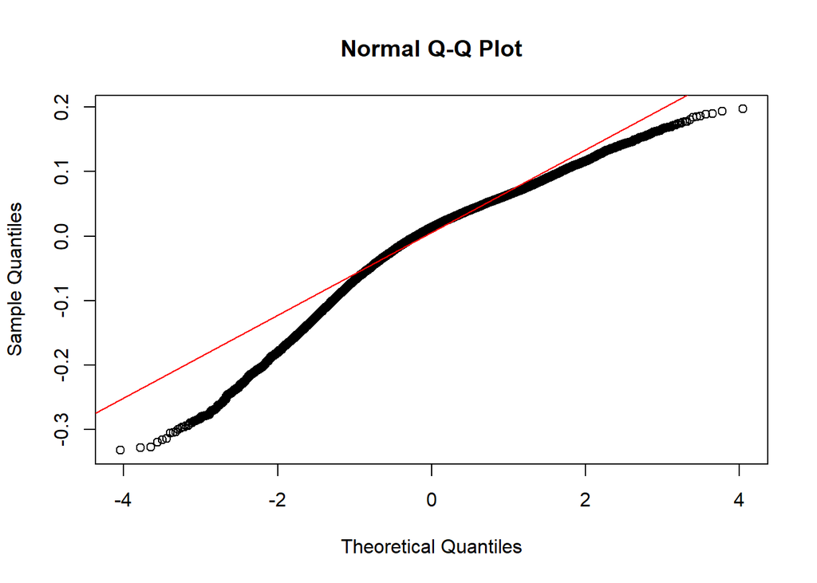

```r
# Q-Q Plot
qqnorm(resid(backward_model), main = "Normal Q-Q Plot")
qqline(resid(backward_model), col = "red")
```

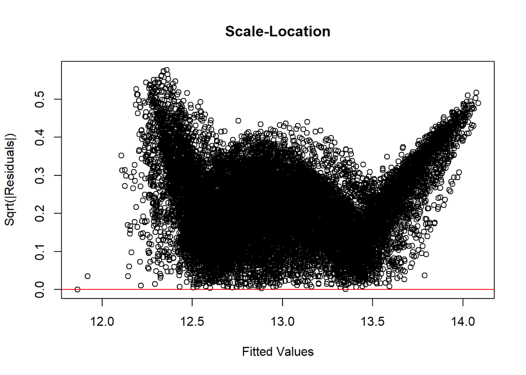

```r
# Scale-Location Plot
plot(sqrt(abs(resid(backward_model))) ~ fitted(backward_model),
     main = "Scale-Location",
     xlab = "Fitted Values",
     ylab = "Sqrt(|Residuals|)")
abline(h = 0, col = "red")
```

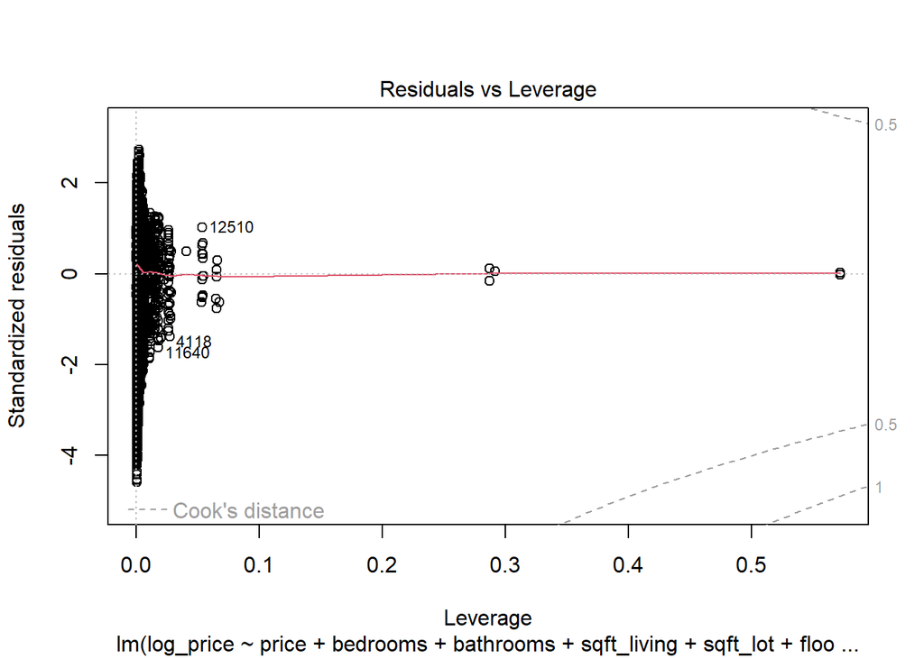

```r
# Residuals vs Leverage
plot(backward_model, which = 5) # Cook's Distance
```

The predictors zipcode, yr_renovated, sqft_lot15, and month_sold were removed from the model as they showed minimal contributions to reducing the residual sum of squares (RSS) and had negligible impact on improving the model’s overall fit, as indicated by their low sum of squares in the backward elimination output. Additionally, these predictors had higher p-values, suggesting they were not statistically significant in explaining the variability in the response variable.

```r
# Updating model to remove insignificant predictors
model_refined <- lm(log_price ~ grade + lat + sqft_living + yr_built +bedrooms+
                      sqft_living15 + floors + condition + view +
                      year_sold + bathrooms + waterfront, data = refined_data)
summary(model_refined)
```

```
##
## Call:
## lm(formula = log_price ~ grade + lat + sqft_living + yr_built +
##     bedrooms + sqft_living15 + floors + condition + view + year_sold +
##     bathrooms + waterfront, data = refined_data)
##
## Residuals:
##      Min       1Q   Median       3Q      Max
## -0.94034 -0.14732  0.00235  0.14306  1.02902
##
## Coefficients:
##                 Estimate Std. Error t value Pr(>|t|)
## (Intercept)   -1.353e+02  6.929e+00 -19.531  < 2e-16 ***
## grade4         1.010e-01  2.748e-01   0.367 0.713269
## grade5         4.590e-02  2.491e-01   0.184 0.853831
## grade6         2.687e-01  2.487e-01   1.081 0.279928
## grade7         4.496e-01  2.487e-01   1.807 0.070721 .
## grade8         6.098e-01  2.488e-01   2.451 0.014258 *
## grade9         7.555e-01  2.489e-01   3.036 0.002402 **
## grade10        8.153e-01  2.490e-01   3.274 0.001063 **
## grade11        8.395e-01  2.504e-01   3.353 0.000801 ***
## lat            1.291e+00  1.190e-02 108.522  < 2e-16 ***
## sqft_living    1.402e-04  4.412e-06  31.786  < 2e-16 ***
## yr_built      -3.386e-03  7.917e-05 -42.772  < 2e-16 ***
## bedrooms      -1.873e-02  2.406e-03  -7.782 7.50e-15 ***
## sqft_living15  1.041e-04  4.340e-06  23.991  < 2e-16 ***
## floors         6.157e-02  3.373e-03  18.252  < 2e-16 ***
## condition2     5.067e-02  1.209e-01   0.419 0.675045
## condition3     2.026e-01  1.174e-01   1.725 0.084485 .
## condition4     2.478e-01  1.174e-01   2.110 0.034869 *
## condition5     3.065e-01  1.175e-01   2.608 0.009107 **
## view1          1.027e-01  1.493e-02   6.877 6.28e-12 ***
## view2          9.784e-02  8.747e-03  11.185  < 2e-16 ***
## view3          9.648e-02  1.439e-02   6.707 2.04e-11 ***
## view4          2.195e-01  3.519e-02   6.238 4.53e-10 ***
## year_sold      4.577e-02  3.418e-03  13.389  < 2e-16 ***
## bathrooms      4.335e-02  3.154e-03  13.746  < 2e-16 ***
## waterfront1    1.766e-01  5.512e-02   3.204 0.001356 **
## ---
## Signif. codes:  0 '***' 0.001 '**' 0.01 '*' 0.05 '.' 0.1 ' ' 1
##
## Residual standard error: 0.2192 on 18969 degrees of freedom
## Multiple R-squared:  0.7125, Adjusted R-squared:  0.7121
## F-statistic:  1880 on 25 and 18969 DF,  p-value: < 2.2e-16
```

```r
# Function to compute metrics for each model
compute_model_metrics <- function(model, data) {
  sse <- sum(residuals(model)^2)
  r2 <- summary(model)$r.squared
  adj_r2 <- summary(model)$adj.r.squared
  aic <- AIC(model)
  bic <- BIC(model)

  # Calculate Cp (Mallow's Cp)
  cp <- sse / (var(model$residuals) * (nrow(data) - length(coef(model)))) + 2 * length(coef(model)) - nrow(data)


  return(data.frame(SSE = sse, R2 = r2, Adj_R2 = adj_r2, AIC = aic, BIC = bic, Cp = cp))
}

# Compute metrics for all models
metrics_refined <- compute_model_metrics(model_refined, refined_data)

# Combine the results
results <- rbind(
  cbind(Model = "Refined", metrics_refined)
)

# Display the table
results
```

```
##     Model      SSE        R2    Adj_R2       AIC       BIC     Cp
## 1 Refined 911.3525 0.7124602 0.7120812 -3728.366 -3516.364 -18942
```

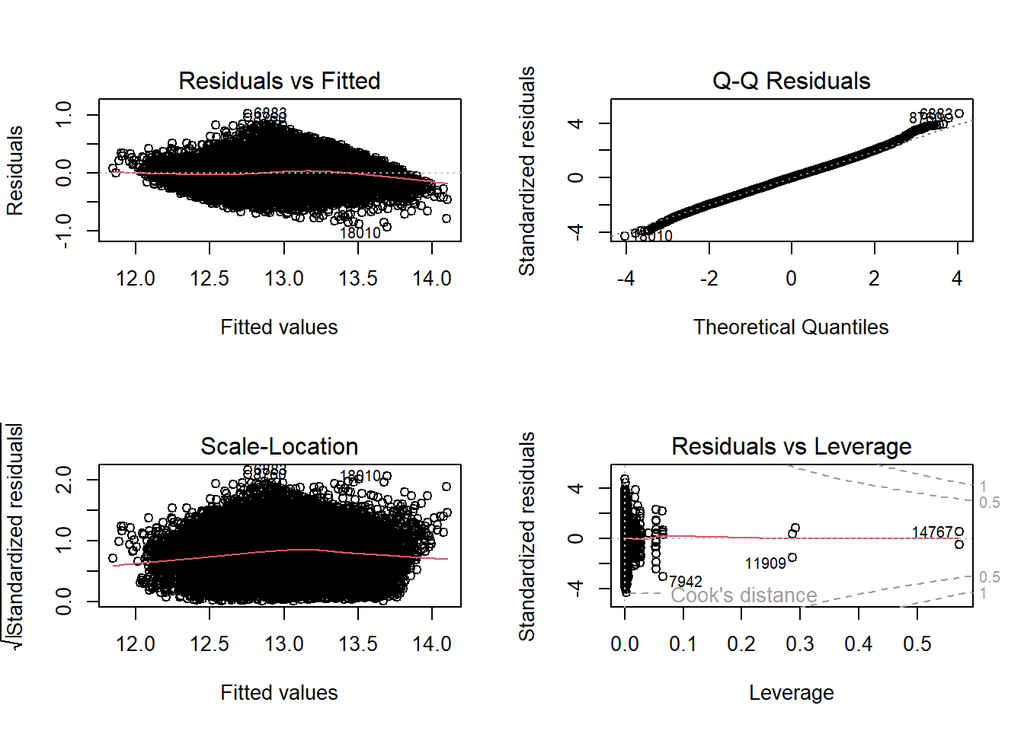

```r
# Plot diagnostic plots for model_refined
par(mfrow = c(2, 2))  # Set up a 2x2 grid for plots
plot(model_refined)
```